# Analyses of GSE138988; GSE224858; GSE224752

Analyses comparing PBodies to Stress Granules

Alexandre Kaizeler[^1] - alexandreafonso@gimm.pt<

23 July 2026

# Introduction

In this document, I present all analyses pertaining to the datasets: * **GSE138988** ([NCBI GEO Link](https://www.ncbi.nlm.nih.gov/geo/query/acc.cgi?acc=GSE138988)),  
originally published by **T. Matheny, 2019**; * **GSE224858** ([NCBI GEO Link](https://www.ncbi.nlm.nih.gov/geo/query/acc.cgi?acc=GSE224858)),  
originally published by **S. Kodali, 2024**; * **GSE224752** ([NCBI GEO Link](https://www.ncbi.nlm.nih.gov/geo/query/acc.cgi?acc=GSE224752)),  
originally published by **S. Kodali, 2024**.

## Libraries

```r
# These are all the libraries I used throughout the analysis. Not all of them will be required on this guidebook
library(Rsubread)
library(limma)
library(edgeR)
library(DESeq2)
library(magrittr)
library(ggrepel)
library(tidyverse)
library(vsn)
library(ggplot2)
library(NMF)
library(biomaRt)
library(ggpubr)
library(factoextra)
library(ggfortify)
library(plotly)
library(reshape2)
library(fgsea)
library(msigdbr)
library(data.table)
library(colorspace)

set.seed(1906)
```

## Loading up the data

```r
#This section here is to load up the genelenght file I will be using throughout the analyses.
genelength <- read.csv("~/Projects/StressGranules/SG_Transcriptome/RP_Data_2021/TrimmedSamples/alignment_STAR/TranscriptLenght.txt", header=T)

genelength <- subset(genelength, Ensembl.Canonical==1)
genelength <- subset(genelength, Gene.name!="")

genelength <- genelength %>%
  group_by(Gene.name) %>%
  slice(which.max(Transcript.length..including.UTRs.and.CDS.)) %>%
  ungroup()

genelength <- genelength[,-c(2,3)]
colnames(genelength) <- c("Length", "Gene")


#First we load up the data from T. Matheny 2019, which uses Differential Centrifugation as a method to isolate PBs.
raw.read.counts <- read.table("~/Projects/StressGranules/SG_Transcriptome/P_Bodies/alignment_STAR/featureCounts_results.txt", header = T)[,-c(2:6)]


#Loading up our biomart file, obtained from Ensembl, where we have the equivalence between Ensembl IDs and HGNC names
biomart <- fread("~/biomart.txt")[,-1]


colnames(raw.read.counts)[1] <- "ensembl_gene_id_version"
colnames(biomart) <- c("ensembl_gene_id_version", "hgnc_symbol")

eltable <- merge(raw.read.counts,biomart,by = "ensembl_gene_id_version", all= TRUE) #this creates a table with both ensemble ids and HGNC codes.

eltable <- subset(eltable, hgnc_symbol!="") #this removes reads that dont have a corresponding hgnc symbol.

eltable$ensembl_gene_id_version <- NULL # We no longer need this column

read.counts <- eltable %>% # If two gene ids resulted in the same gene name, this will sum up their counts
  group_by(hgnc_symbol) %>%
  summarise(across(everything(), sum, na.rm = TRUE))
read.counts <- as.data.frame(read.counts)

row.names(read.counts) <- read.counts$hgnc_symbol #changes rownames into hgnc symbols
read.counts$hgnc_symbol <- NULL #We no longer need this column, as we have the rownames.
```

## Extra Quality Control

Let’s check for sample complexity. It is possible that one or more samples have different complexity. In specific, I am going to check if enough reads have been obtained from every sample. If not, we should have a great bias to housekeeping genes. Another way to put it, is to say that even with all reads, we won’t obtain a great deal of different genes.

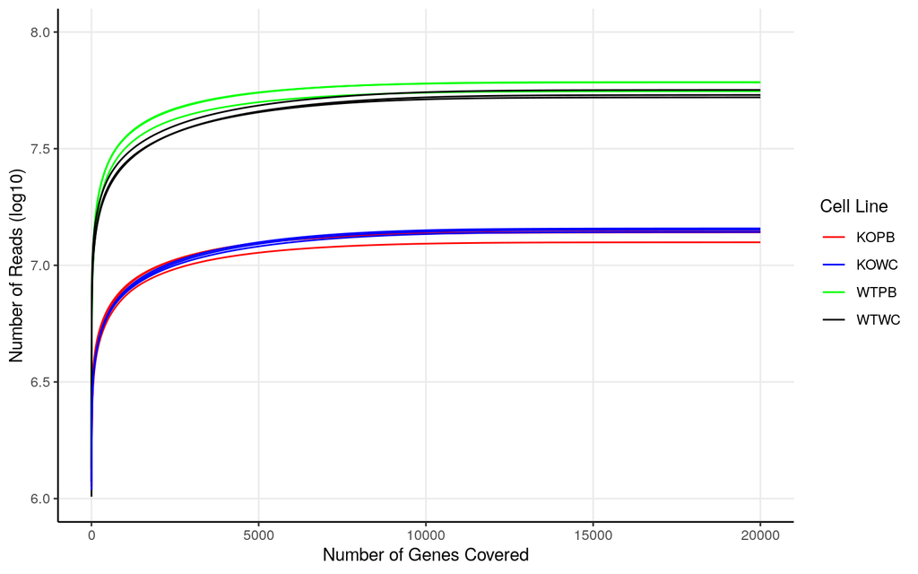

```r
# Define color palette
custom_palette <- c("red", "blue", "green", "black")

# Variable that I wish to colour
SampleColouring <- c(rep("WTPB",3), rep("KOPB",3), rep("WTWC",3), rep("KOWC", 3))

# Build cumulative counts
final <- sapply(1:ncol(read.counts), function(i) {
  sort_vals <- read.counts[order(read.counts[, i], decreasing = TRUE), i]
  cumsum(sort_vals)
})
final <- as.data.frame(final)
colnames(final) <- colnames(read.counts)

# Melt and add gene position + sample info
finalmelt <- reshape2::melt(final, variable.name = "Sample")
finalmelt$genes <- rep(1:nrow(final), times = ncol(final))
finalmelt$SampleColouring <- rep(SampleColouring, each = nrow(final))

# Plot cumulative read coverage
ggplot(data = finalmelt, aes(x = genes, y = log10(value), group = Sample, color = SampleColouring)) +
  geom_line() +
  scale_color_manual(values = custom_palette, name = "Cell Line") +
  theme_bw() +
  xlab("Number of Genes Covered") +
  ylab("Number of Reads (log10)") +
  xlim(0, 20000) +
  ylim(6, 8) +
  theme(
    axis.line = element_line(colour = "black"),
    panel.grid.minor = element_blank(),
    panel.border = element_blank(),
    panel.background = element_blank()
  )
```

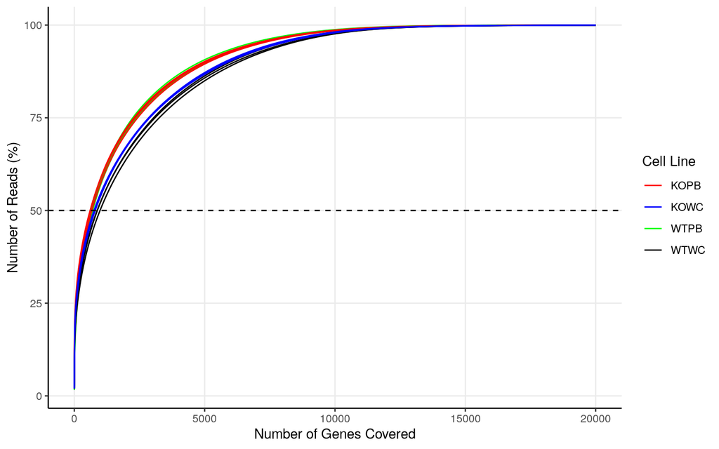

```r
# Create percentage-based plot
orderfinal <- subset(finalmelt, genes == max(finalmelt$genes))
trial <- merge(orderfinal[, c("Sample", "value")], finalmelt, by = "Sample", suffixes = c(".total", ".current"))
trial$percent <- (trial$value.current / trial$value.total) * 100
trial$SampleColouring <- rep(SampleColouring, each = nrow(final))

ggplot(data = trial, aes(x = genes, y = percent, group = Sample, color = SampleColouring)) +
  geom_line() +
  geom_hline(yintercept = 50, linetype = "dashed") +
  scale_color_manual(values = custom_palette, name = "Cell Line") +
  xlab("Number of Genes Covered") +
  ylab("Number of Reads (%)") +
  xlim(0, 20000) +
  theme_bw() +
  theme(
    axis.line = element_line(colour = "black"),
    panel.grid.minor = element_blank(),
    panel.border = element_blank(),
    panel.background = element_blank()
  )
```

As we can see in these plots, there are some differences in accordance to sample type. It seems samples KO for G3BP1/2 have a lower read depth, and that PBody samples have lower complexity. Nevertheless, no individual sample behaves vastly different than its same type counterparts, so we can proceed.

# Differential Expression Analysis

## Filtration

### *Before Filtration*

Let us begin with the filtration. Personally, I find that its easier to do visually. I am aware that my filtration is more violent than most. Usually, from RNA-Seq experiments, we commonly obtain bi-modal distributions, with the first mode corresponding to lowly expressed genes. I remove these by cutting just before the second mode. This time, I opted to also observe every sample type by itself.

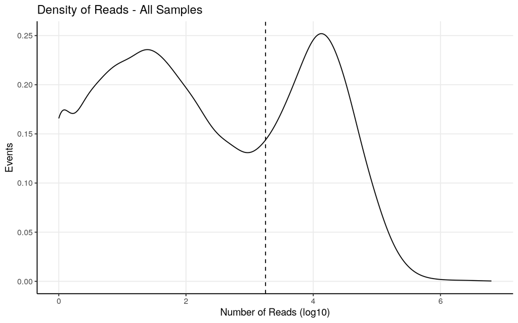

```r
alternew.sg.unstressed <- log10(rowSums(read.counts[,1:3]))
alternew.sg.unstressed <- as.data.frame(alternew.sg.unstressed)

alternew.sg.stressed <- log10(rowSums(read.counts[,4:6]))
alternew.sg.stressed <- as.data.frame(alternew.sg.stressed)

alternew.bu.unstressed <- log10(rowSums(read.counts[,7:9]))
alternew.bu.unstressed <- as.data.frame(alternew.bu.unstressed)

alternew.bu.stressed <- log10(rowSums(read.counts[,10:12]))
alternew.bu.stressed <- as.data.frame(alternew.bu.stressed)

alternew <- log10(rowSums(read.counts))
alternew <- as.data.frame(alternew)

ggplot(alternew, aes(x=alternew)) + geom_density() + theme_bw() + geom_vline(xintercept = 3.25, linetype = "dashed") + ylab("Events") + xlab("Number of Reads (log10)") +
  theme(axis.line = element_line(colour = "black"),
        panel.grid.minor = element_blank(),
        panel.border = element_blank(),
        panel.background = element_blank()) + ggtitle("Density of Reads - All Samples")
```

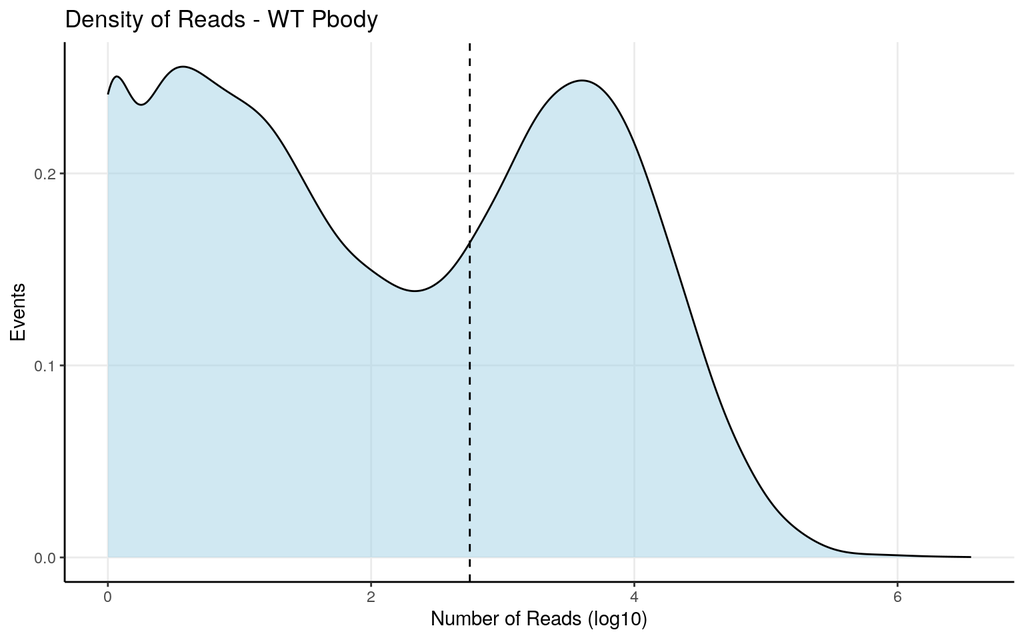

```r
ggplot(alternew.sg.unstressed, aes(x=alternew.sg.unstressed)) + geom_density(fill="#a2d1e6", alpha=0.5) + theme_bw() + geom_vline(xintercept = 2.75, linetype = "dashed") + ylab("Events") + xlab("Number of Reads (log10)") +
  theme(axis.line = element_line(colour = "black"),
        panel.grid.minor = element_blank(),
        panel.border = element_blank(),
        panel.background = element_blank()) + ggtitle("Density of Reads - WT Pbody")
```

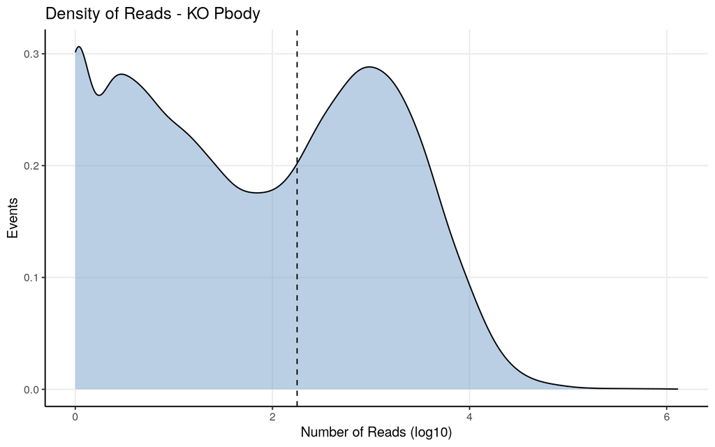

```r
ggplot(alternew.sg.stressed, aes(x=alternew.sg.stressed)) + geom_density(fill="#769fca", alpha=0.5) + theme_bw() + geom_vline(xintercept = 2.25, linetype = "dashed") + ylab("Events") + xlab("Number of Reads (log10)") +
  theme(axis.line = element_line(colour = "black"),
        panel.grid.minor = element_blank(),
        panel.border = element_blank(),
        panel.background = element_blank()) + ggtitle("Density of Reads - KO Pbody")
```

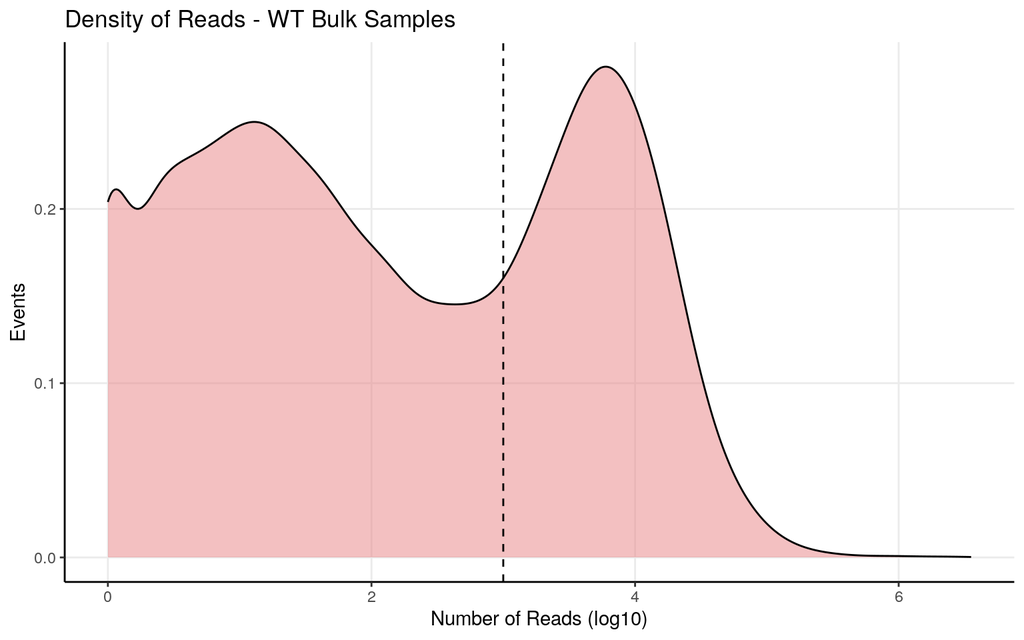

```r
ggplot(alternew.bu.unstressed, aes(x=alternew.bu.unstressed)) + geom_density(fill="#e88184", alpha=0.5) + theme_bw() + geom_vline(xintercept = 3, linetype = "dashed") + ylab("Events") + xlab("Number of Reads (log10)") +
  theme(axis.line = element_line(colour = "black"),
        panel.grid.minor = element_blank(),
        panel.border = element_blank(),
        panel.background = element_blank()) + ggtitle("Density of Reads - WT Bulk Samples")
```

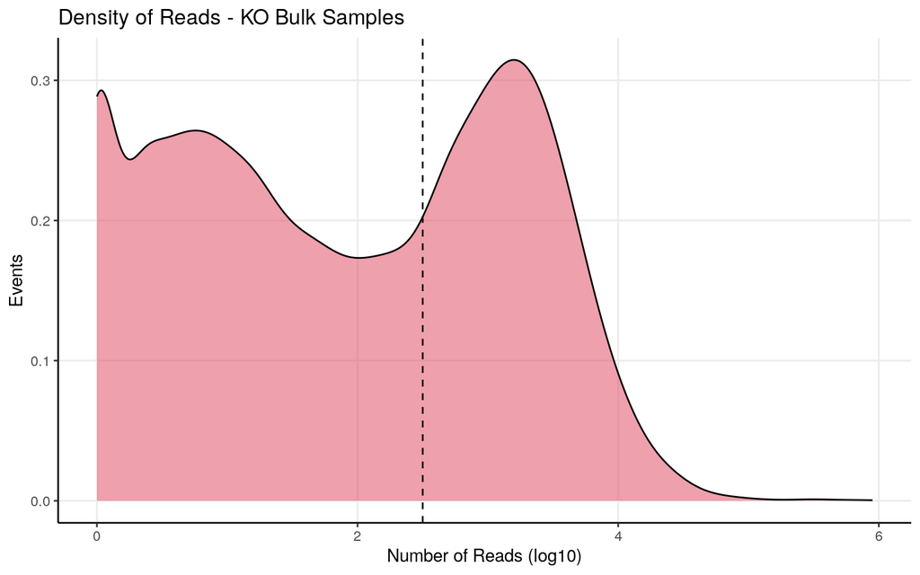

```r
ggplot(alternew.bu.stressed, aes(x=alternew.bu.stressed)) + geom_density(fill="#de425b", alpha=0.5) + theme_bw() + geom_vline(xintercept = 2.5, linetype = "dashed") + ylab("Events") + xlab("Number of Reads (log10)") +
  theme(axis.line = element_line(colour = "black"),
        panel.grid.minor = element_blank(),
        panel.border = element_blank(),
        panel.background = element_blank()) + ggtitle("Density of Reads - KO Bulk Samples")
```

By seeing the shape of the graph, we can see where we should cut. We have a **binomial distribution** (low reads and noise vs actual biological meaningful reads). The ideal place to cut them is right after the wedge.

### *After Filtration*

I didn’t do it this time, but I’ve maintained the code to filter by sample type. This time, I considered that it was more correct to filter all samples together.

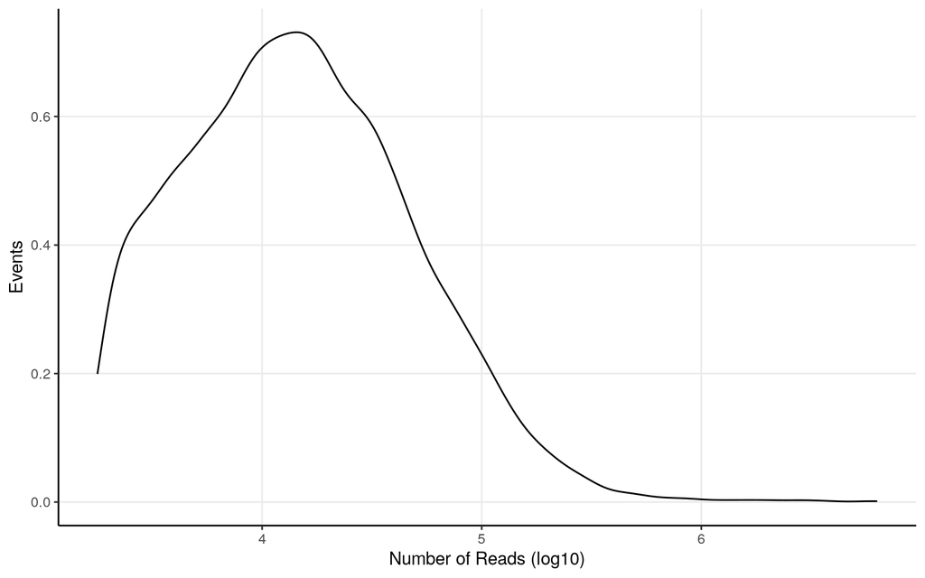

```r
#Here is my filtration itself.
filterednew <- subset(read.counts, alternew>3.25)
filterednew.sgu <- subset(read.counts, alternew.sg.unstressed>2.75)
filterednew.sgs <- subset(read.counts, alternew.sg.stressed>2.25)
filterednew.buu <- subset(read.counts, alternew.bu.unstressed>3)
filterednew.bus <- subset(read.counts, alternew.bu.stressed>2.5)

#after cutting, its a good idea to visualise again
falternew <- log10(rowSums(filterednew))
falternew <- as.data.frame(falternew)
ggplot(falternew, aes(x=falternew)) + geom_density() + theme_bw() + ylab("Events") + xlab("Number of Reads (log10)") +
  theme(axis.line = element_line(colour = "black"),
        panel.grid.minor = element_blank(),
        panel.border = element_blank(),
        panel.background = element_blank())
```

```r
#lets save the genes which we maintain
impgenes <- c(row.names(falternew))
impgenes.sgu <- c(row.names(filterednew.sgu))
impgenes.sgs <- c(row.names(filterednew.sgs))
impgenes.buu <- c(row.names(filterednew.buu))
impgenes.bus <- c(row.names(filterednew.bus))

#Now we need to select only the rows which have those genes.
finaltable <- read.counts[row.names(read.counts)%in%impgenes,]
#finaltable <- finaltable[row.names(finaltable)%in%impgenes.sgu,]
#finaltable <- finaltable[row.names(finaltable)%in%impgenes.sgs,]
#finaltable <- finaltable[row.names(finaltable)%in%impgenes.buu,]
#finaltable <- finaltable[row.names(finaltable)%in%impgenes.bus,]
```

## Matrices

Good! Now we can proceed by designing our matrices.

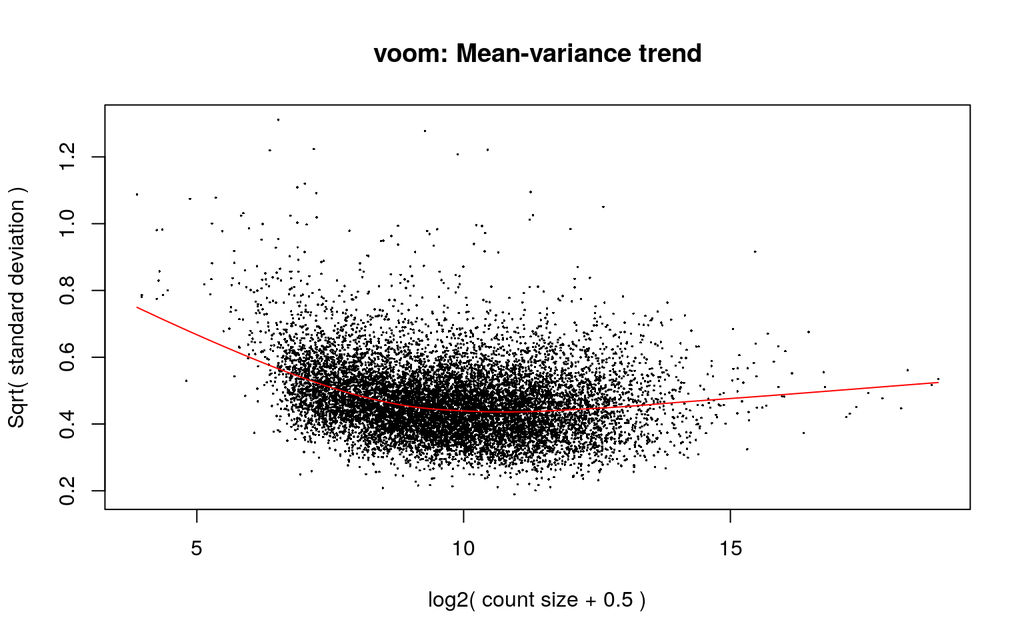

```r
#Let us prepare metadata to add to our samples
#This time, we have two main variables. Sample type, and G3BP1/2 status.
sampletype <- c(rep("PBody",6), rep("WC",6))
g3state <- c(rep("WT",3), rep("KO",3),rep("WT",3), rep("KO",3))

#To be able to use Voom, we must first convert our read count table into a special DGE object.
D0 <- DGEList(finaltable)

#Then we calculate the normalisation factors.
#Bear in mind this step calculates the normalisation factors, but does not normalise itself.
D0 <- calcNormFactors(D0)


#Now we do our matrix itself
mm <- model.matrix(~0+sampletype+g3state)

#and now we normalise. This step also turns our counts into log2-counts per million.
y <- voom(D0, mm, plot = T)
```

## Normalisation

Now, we are almost ready to move on to the differential gene expression analysis. I will first check to see if any issues arose during the normalisation process, by looking at samples before and after this process.

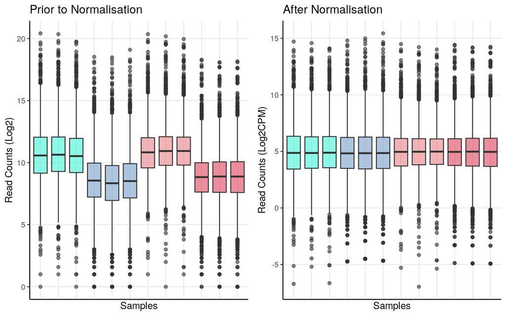

```r
dfforboxy <- finaltable

orderforplots <- SampleColouring
colouring <- data.frame(Sample=colnames(dfforboxy), Types=orderforplots)
dfforboxy <- reshape2::melt(dfforboxy)
colnames(dfforboxy) <- c("Sample", "Expression")
dfforboxy <- merge(dfforboxy, colouring, by="Sample")
prenorm <- ggplot(dfforboxy, aes(x=Sample, y=(log2(Expression+1)), fill=Types)) + geom_boxplot(alpha=0.6) + theme_bw() + ylab("Read Counts (Log2)") + xlab("Samples") + scale_fill_manual(name = "Sample Type", values = c("#43F3D5", "#769fca", "#e88184", "#de425b"), labels=unique(SampleColouring), breaks =unique(SampleColouring)) +
  theme(axis.line = element_line(colour = "black"),
        panel.grid.minor = element_blank(),
        panel.border = element_blank(),
        panel.background = element_blank(),
        axis.text.x=element_blank(),
        axis.ticks.x=element_blank(),
        legend.position = "None") + ggtitle("Prior to Normalisation")

dfforboxy <- y$E
dfforboxy <- reshape2::melt(dfforboxy)
dfforboxy <- dfforboxy[,-1]
colnames(dfforboxy) <- c("Sample", "Expression")
dfforboxy <- merge(dfforboxy, colouring, by="Sample")
postnorm <- ggplot(dfforboxy, aes(x=Sample, y=Expression, fill=Types)) + geom_boxplot(alpha=0.6) + theme_bw() + ylab("Read Counts (Log2CPM)") + xlab("Samples") + scale_fill_manual(name = "Sample Type", values = c("#43F3D5", "#769fca", "#e88184", "#de425b"), labels=unique(SampleColouring), breaks =unique(SampleColouring)) +
  theme(axis.line = element_line(colour = "black"),
        panel.grid.minor = element_blank(),
        panel.border = element_blank(),
        panel.background = element_blank(),
        axis.text.x=element_blank(),
        axis.ticks.x=element_blank(),
        legend.position = "None") + ggtitle("After Normalisation")

ggarrange(prenorm, postnorm, nrow=1)
```

In this case, from the boxplots, we can see that there no samples which can be considered outliers.

## PCA

I like to start with a Principal Component Analysis (PCA), which helps to identify what drives the largest variation in the data.

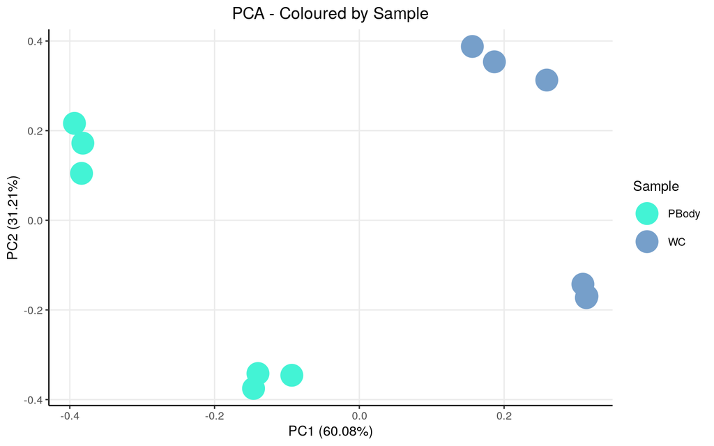

```r
#In here, I am just defining some colours to use
custom_palette <- c("#43F3D5", "#769fca", "#e88184", "#de425b")

#This prepares my data for the PCA
dfforpca <- y$E
dfforpca <- t(dfforpca)
dfforpca <- as.data.frame(dfforpca) # needs to be a data.frame
dfforpca <- apply(dfforpca, 2, as.numeric) # Ensure numeric
dfforpca <- as.data.frame(dfforpca) # still needs to be a data.frame

# Add metadata, which we will then use to plot
dfforpca$Sample <- sampletype
dfforpca$G3 <- g3state

# PCA computation itself. I do one PCA for each variable I want to see.
pca_res <- prcomp(dfforpca[, 1:(ncol(dfforpca)-2)], scale = FALSE)

p_Sample <- autoplot(pca_res, data = dfforpca, x = 1, y = 2, colour = "Sample", size = 8) +
  theme_bw() +
  scale_colour_manual(name = "Sample", values = custom_palette) +
  ggtitle("PCA - Coloured by Sample") +
  theme(plot.title = element_text(hjust = 0.5),
        axis.line = element_line(colour = "black"),
        panel.grid.minor = element_blank(),
        panel.border = element_blank(),
        panel.background = element_blank())
p_g3 <- autoplot(pca_res, data = dfforpca, x = 1, y = 2, colour = "G3", size = 8) +
  theme_bw() +
  scale_colour_manual(name = "G3", values = custom_palette) +
  ggtitle("PCA - Coloured by G3") +
  theme(plot.title = element_text(hjust = 0.5),
        axis.line = element_line(colour = "black"),
        panel.grid.minor = element_blank(),
        panel.border = element_blank(),
        panel.background = element_blank())

p_Sample
```

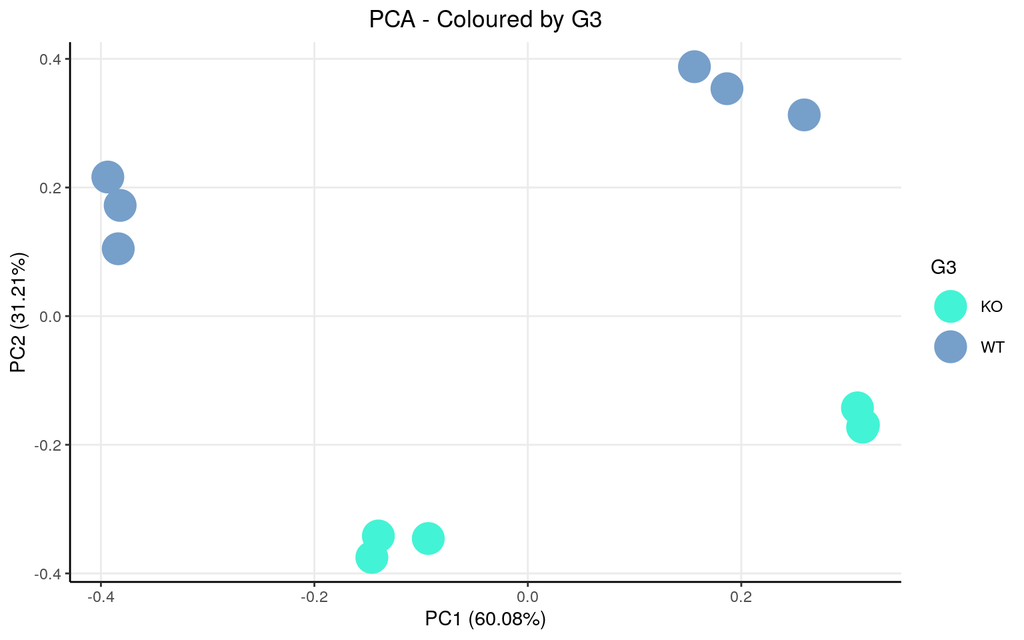

```r
p_g3
```

```r
#in case you want to see most important genes for PCA yourself
contribs1 <- pca_res$rotation[,1]
contribs2 <- pca_res$rotation[,2]

#These are the biggest contributors to the PCA1 (right side)
(pos1genes <- sort(contribs1, decreasing=T)[1:10])
```

```
##     RN7SL3     RN7SL2     RN7SL1    RN7SL4P      RPPH1      RN7SK        7SK
## 0.06180786 0.06094374 0.06035071 0.05912933 0.05793859 0.04798605 0.04797165
##      GTSF1       DLX2       MT1G
## 0.03934072 0.03729230 0.03719092
```

```r
#These are the biggest contributors to the PCA1 (left side)
(neg1genes <- sort(contribs1, decreasing=F)[1:10])
```

```
##       MT-TR       MT-TG      MT-TL2      MT-TS2       MT-TH      MT-TS1
## -0.04444783 -0.04331353 -0.04074673 -0.03962374 -0.03931599 -0.03136753
##        CUX2     SHISAL1       MT-TD     COL11A1
## -0.02943479 -0.02873074 -0.02836122 -0.02691136
```

```r
#These are the biggest contributors to the PCA2 (up side)
(pos2genes <- sort(contribs2, decreasing=T)[1:10])
```

```
##     DPYSL5        NTM      KRT81      TRAF3      PAGE2       H3Y1     MFSD2A
## 0.08653772 0.08490149 0.08420153 0.08407041 0.08395588 0.07846003 0.07597347
##      TTLL7      GSTM3      H2AC8
## 0.07531139 0.07464282 0.07233963
```

```r
#These are the biggest contributors to the PCA2 (down side)
(neg2genes <- sort(contribs2, decreasing=F)[1:10])
```

```
##     SLC17A9     MAGEA10       GTSF1        ZEB2        DLX2   LINC01287
## -0.10933182 -0.10700782 -0.09002572 -0.08853441 -0.08255583 -0.07646165
##       ICAM1   ICAM4-AS1      TRIML2        MT1G
## -0.06965940 -0.06850152 -0.06750977 -0.06741346
```

As one can observe from the PCAs, our PC1 is mostly explained by sample type, while our PC2 is explained by if G3BP1/2 is KO or not.

## Linear Models

Finally, we move on to differential gene expression! In this chunk, I define the linear model I will actually use for my analyses.

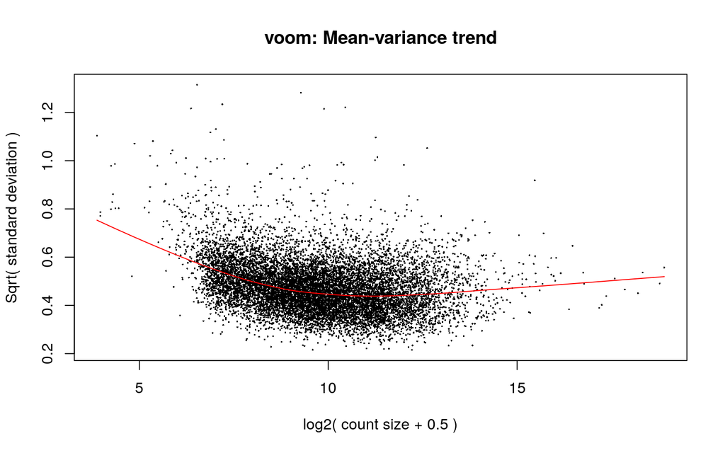

```r
#Here, I define the variables I am interested in. In this case, I am interested in sample type variable. However, I also supply the effect of being Ko for G3BP1/2.
mm <- model.matrix(~0+sampletype+g3state) #The 0~ means I am not considering any sample as the baseline. In the end, this ends up being a bit of personal preference. I find that its easier to interpret if no samples are baselines.

# Don't forget, use corrected counts here
y <- voom(finaltable, mm, plot = T)
```

```r
#We now fit the linear model to our expression
fitted <- lmFit(y,mm)

#To check our coefficients
head(coef(fitted))
```

```
##          sampletypePBody sampletypeWC  g3stateWT
## 7SK            8.5178019    14.334431 -1.0342439
## A1BG           1.1259860     2.561745  0.5165446
## A1BG-AS1       3.4028012     2.604123  0.2253324
## A2M            0.7537432     1.199236  1.4252032
## AAAS           4.7068010     6.225954 -0.8489466
## AACS           5.3391936     5.728418 -0.6191206
```

```r
#next we measure contrasts between groups (log-fold change is obtained from these fitted linear models)
contr<- makeContrasts(sampletypePBody  - sampletypeWC  , levels = colnames(coef(fitted)))

#next we estimate the contrast for each gene
tmp <- contrasts.fit(fitted, contr)


#Correction for multiple testing. This is very important, as with so many tests, a ton of transcripts will otherwise achieve very low p-values, simply by random chance.
tmp <- eBayes(tmp)
top.table <- topTable(tmp, sort.by = "logFC", n = Inf)
DEGenes <- top.table
ndegs=20
```

## PBody vs WC (Differential Centrifugation)

Now, we simply see all of this on a volcano plot. Personally, I prefer my significance to be given by B-statistic, since adjusted p-values easily saturate at values closer to 0. As B-statistic is an “infinite” scale, this doesn’t occur.

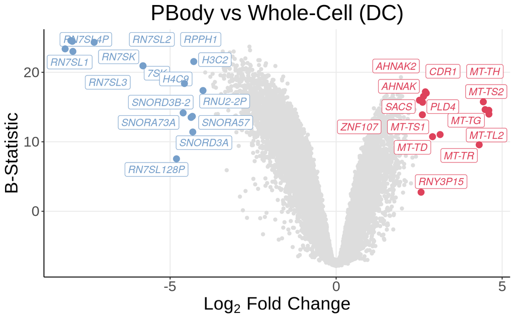

```r
upmarkers <- as.data.frame(DEGenes[DEGenes$logFC>2.5 & DEGenes$adj.P.Val<0.05,] )
downmarkers <- as.data.frame(DEGenes[DEGenes$logFC< -4 & DEGenes$adj.P.Val<0.05,] )

ggplot(data=DEGenes,
                 aes(x=logFC,
                     y=  B)) +
  geom_point(color="#DDDDDD")+
  theme_bw() +
  theme(axis.line = element_line(colour = "black"),
        panel.grid.minor = element_blank(),
        panel.border = element_blank(),
        panel.background = element_blank()) +
  ggtitle("PBody vs Whole-Cell (DC)")+
  theme(plot.title = element_text(hjust = 0.5)) +
  geom_label_repel(upmarkers[1:ndegs,] , mapping=aes(label=row.names(upmarkers)[1:ndegs]),size=4,point.padding=-0.5, color="#de425b",max.overlaps = 200, fontface="italic")+
  geom_label_repel(downmarkers[1:ndegs,] , mapping=aes(label=row.names(downmarkers)[1:ndegs]),size=4,point.padding=-0.5, color="#769fca",max.overlaps = 200, fontface="italic")+
  geom_point(data=upmarkers, aes(x=logFC, y=  B), color="#de425b", size=3)+
  geom_point(data=downmarkers, aes(x=logFC, y=  B), color="#769fca", size=3) + xlab(expression(Log[2] ~ Fold ~ Change)) + ylab("B-Statistic") + theme(text=element_text(family = "Arial", size = 20))
```

```r
write.table(DEGenes, "~/Projects/StressGranules/SGPAPER/Pboddata.txt", row.names = T)
```

From the volcano, most downregulated genes are small nuclear and nucleolar RNAs, while most upregulated transcripts are either long, or mitocondrially encoded. Curiously, this mirrors extremely well what we saw with stress granule enrichment.

[figure not shown]

```r
DEGenes$Gene <- row.names(DEGenes)
colnames(genelength) <- c("Length","Gene")
DEGenes <- merge(DEGenes, genelength, by="Gene")

Pbody <- DEGenes[,c(1,2,4,8)]

ggplot(data=DEGenes,
                 aes(x=logFC,
                     y=  B)) +
  geom_point(aes(color=log10(Length)))+
  theme_bw() +
  theme(axis.line = element_line(colour = "black"),
        panel.grid.minor = element_blank(),
        panel.border = element_blank(),
        panel.background = element_blank()) +
  ggtitle("SG vs No-SG")+ xlab(expression(Log[2] ~ Fold ~ Change)) + ylab("B-Statistic") +
  theme(plot.title = element_text(hjust = 0.5))  +
  scale_colour_gradient(low = "black", high = "red")+ theme(text=element_text(family = "Quicksand"))
```

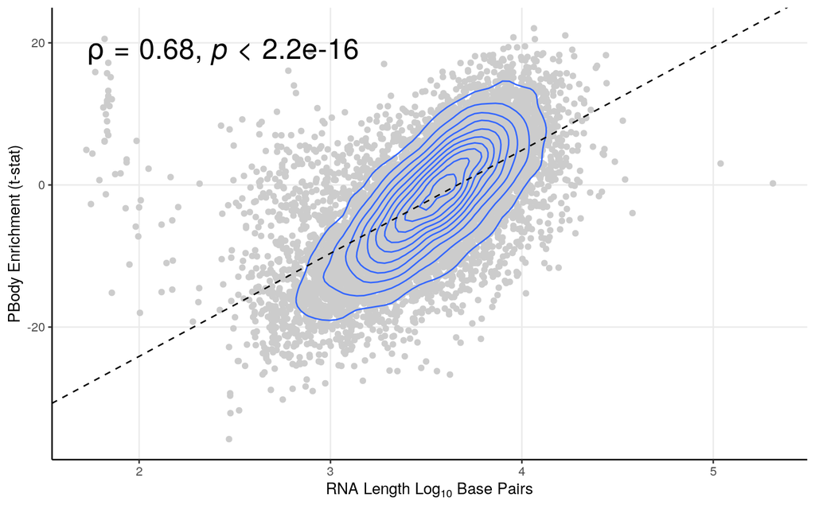

```r
smooth.SG <- lm(t~log10(Length), DEGenes)
liner.SG <- rstandard(smooth.SG)
DEGenes <-cbind(DEGenes, liner.SG)
colnames(DEGenes)[9] <- "Residuals"
row.names(DEGenes) <- DEGenes$Gene
linemarkers <- as.data.frame(DEGenes[abs(DEGenes$Residuals)>4,])

# Calculate the Spearman correlation coefficient
spearman_corr <- cor(DEGenes$t, log10(DEGenes$Length), method = "pearson")



ggplot(DEGenes, aes(y=t, x=log10(Length))) + geom_point(color="#CCCCCC", alpha=1) +   theme_bw()+ geom_density_2d()+
 ylab("PBody Enrichment (t-stat)") + xlab(expression(RNA ~ Length ~ Log[10] ~ Base ~ Pairs)) +
  theme(axis.line = element_line(colour = "black"),
        panel.grid.minor = element_blank(),
        panel.border = element_blank(),
        panel.background = element_blank()) +
  theme(plot.title = element_text(hjust = 0.5))  +
  geom_abline(slope=smooth.SG$coefficients[2], intercept = smooth.SG$coefficients[1], linetype = "dashed")+ stat_cor(method = "spearman", cor.coef.name = "rho",size=7)
```

And in terms of RNA Length, we once again mirror SG enrichment, with longer transcripts being enriched in PBodies.

# Comparison with RNP Granule and SG (isolated by DC)

Now, I suspect that samples isolated through differential centrifugation, all exhibit similar patterns. Therefore, I will compare both RNP Granules, and SG isolated through this technique, with the PBodies.

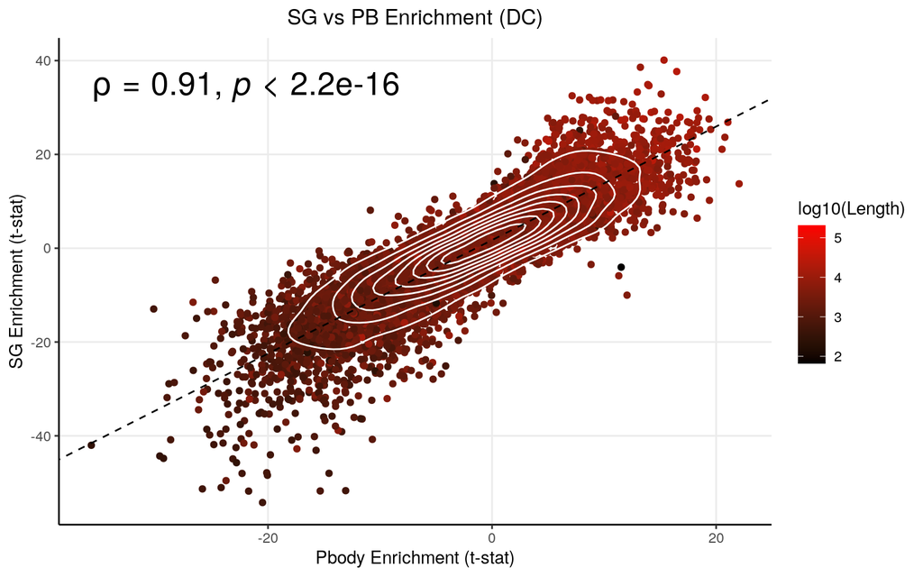

```r
#These files were obtained from other analyses. Respectively, from T. Matheny 2019 and A. Khong 2017.
RNP <- read.table("~/Projects/StressGranules/SGPAPER/SGvsWC/TMatheny2019.txt")
RNP$Gene <- row.names(RNP)
RNP <- RNP[,c(7,3)]
colnames(RNP) <- c("Gene", "RNP")

SG <- read.table("~/Projects/StressGranules/SGPAPER/SGvsWC/Akhong2017.txt")
SG$Gene <- row.names(SG)
SG <- SG[,c(7,3)]
colnames(SG) <- c("Gene", "SG")

DF_for_correl <- merge(Pbody, RNP, by="Gene")
DF_for_correl <- merge(DF_for_correl, SG, by="Gene")



smooth.SG <- lm(SG~(t), DF_for_correl)

ggplot(DF_for_correl, aes(y=SG, x=(t))) + geom_point(aes(colour=log10(Length)), alpha=1) +   theme_bw()+ geom_density_2d(colour="#FFFFFF")+
 ylab("SG Enrichment (t-stat)") + xlab("Pbody Enrichment (t-stat)") + scale_colour_gradient(low="black", high="red")+ ggtitle("SG vs PB Enrichment (DC)")+
  theme(axis.line = element_line(colour = "black"),
        panel.grid.minor = element_blank(),
        panel.border = element_blank(),
        panel.background = element_blank()) +
  theme(plot.title = element_text(hjust = 0.5))  +
  geom_abline(slope=smooth.SG$coefficients[2], intercept = smooth.SG$coefficients[1], linetype = "dashed")+ stat_cor(method = "spearman", cor.coef.name = "rho",size=7)
```

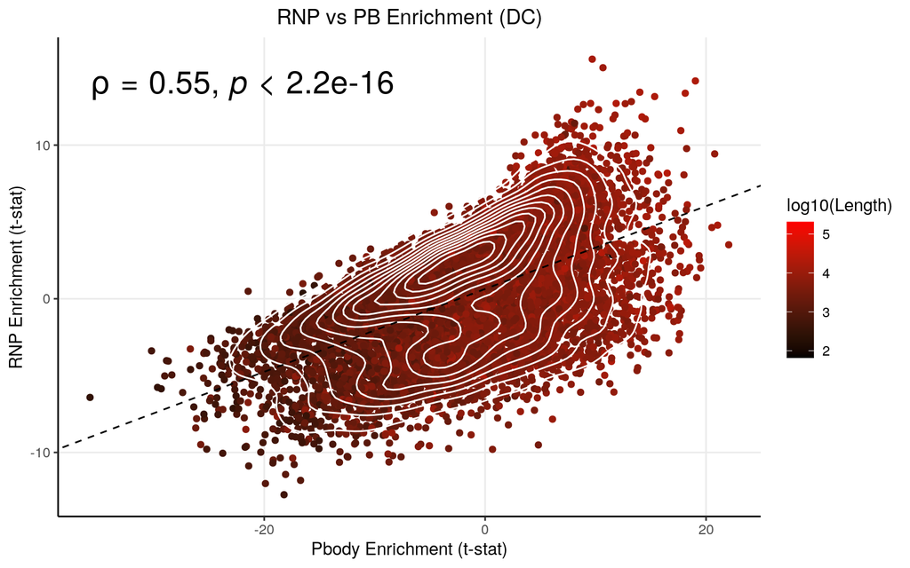

```r
smooth.SG <- lm(RNP~(t), DF_for_correl)

ggplot(DF_for_correl, aes(y=RNP, x=(t))) + geom_point(aes(colour=log10(Length)), alpha=1) +   theme_bw()+ geom_density_2d(colour="#FFFFFF")+
 ylab("RNP Enrichment (t-stat)") + xlab("Pbody Enrichment (t-stat)") + scale_colour_gradient(low="black", high="red")+ ggtitle("RNP vs PB Enrichment (DC)")+
  theme(axis.line = element_line(colour = "black"),
        panel.grid.minor = element_blank(),
        panel.border = element_blank(),
        panel.background = element_blank()) +
  theme(plot.title = element_text(hjust = 0.5))  +
  geom_abline(slope=smooth.SG$coefficients[2], intercept = smooth.SG$coefficients[1], linetype = "dashed")+ stat_cor(method = "spearman", cor.coef.name = "rho",size=7)
```

Now, we can see that SGs are remarkably similar to PB, at least when both are stressed. They are basically replicates. The stressed RNP granule also shares similarity, albeit lower. The RNP granule in theory has both SGs and PBodies, as well as other granules. Still, I find it curious that a “part of a whole is more similar to the other part, than to the whole”, but this can be explained if the other 3rd part is vastly different. I would argue that one cannot exclude that the similarity is lower simply because there is one less round of centrifugation.

# Direct Comparison with Other Samples

Above, the datasets were analysed individually, and then I was “checking the signal”. To control for normalisation and filtration, I decided to repeat the comparison, but first by integrating the datasets.

## Introduction

```r
pbodies <- read.table("~/Projects/StressGranules/SG_Transcriptome/P_Bodies/alignment_STAR/featureCounts_results.txt", header = T)[,-c(2:6)]
pbodies <- pbodies[,c(1:4,8:10)]

#From T Matheny 2019
rnpgrany <- read.table("~/Projects/StressGranules/SG_Transcriptome/RP_Data_2019/TrimmedSamples/alignment_STAR/featureCounts_results.txt", header=TRUE)[,c(1,10:12,16:18)]

#From A Khong 2017
SG <- read.table("~/Projects/StressGranules/SG_Transcriptome/RP_Data_2017/TrimmedSamples/alignment_STAR/featureCounts_results.txt", header=TRUE)[,c(1,7:12)]

granules <- merge(pbodies, rnpgrany, by="Geneid")
raw.read.counts <- merge(granules, SG, by="Geneid")


#Loading up our biomart file, obtained from Ensembl, where we have the equivalence between Ensembl IDs and HGNC names
biomart <- fread("~/biomart.txt")[,-1]


colnames(raw.read.counts)[1] <- "ensembl_gene_id_version"
colnames(biomart) <- c("ensembl_gene_id_version", "hgnc_symbol")
eltable <- merge(raw.read.counts,biomart,by = "ensembl_gene_id_version", all= TRUE) #this creates a table with both ensemble ids and HGNC codes.

eltable <- subset(eltable, hgnc_symbol!="")#this removes reads that dont have a corresponding hgnc symbol.
eltable$ensembl_gene_id_version <- NULL
read.counts <- eltable %>%
  group_by(hgnc_symbol) %>%
  summarise(across(everything(), sum, na.rm = TRUE))

read.counts <- as.data.frame(read.counts)

row.names(read.counts) <- read.counts$hgnc_symbol #changes rownames into hgnc symbols
read.counts$hgnc_symbol <- NULL
```

## Filtration

### *Before Filtration*

Let us begin with the filtration. Personally, I find that its easier to do visually. I am aware that my filtration is more violent than most. Usually, from RNA-Seq experiments, we commonly obtain bi-modal distributions, with the first mode corresponding to lowly expressed genes. I remove these by cutting just before the second mode. This time, I opted to also observe every sample type by itself.

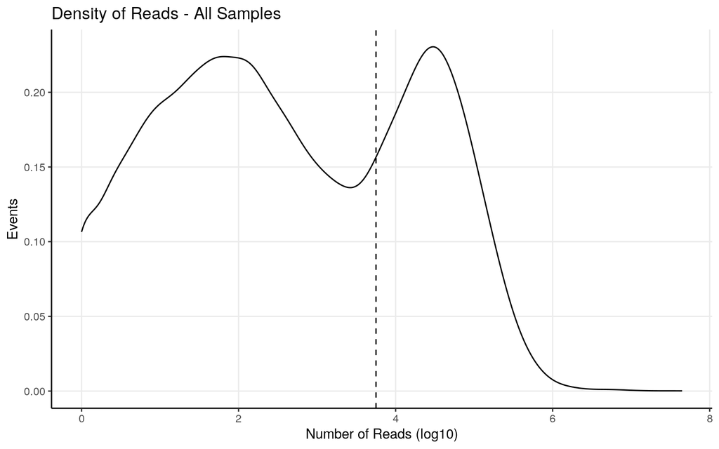

```r
alternew <- log10(rowSums(read.counts))
alternew <- as.data.frame(alternew)

ggplot(alternew, aes(x=alternew)) + geom_density() + theme_bw() + geom_vline(xintercept = 3.75, linetype = "dashed") + ylab("Events") + xlab("Number of Reads (log10)") +
  theme(axis.line = element_line(colour = "black"),
        panel.grid.minor = element_blank(),
        panel.border = element_blank(),
        panel.background = element_blank()) + ggtitle("Density of Reads - All Samples")
```

### *After Filtration*

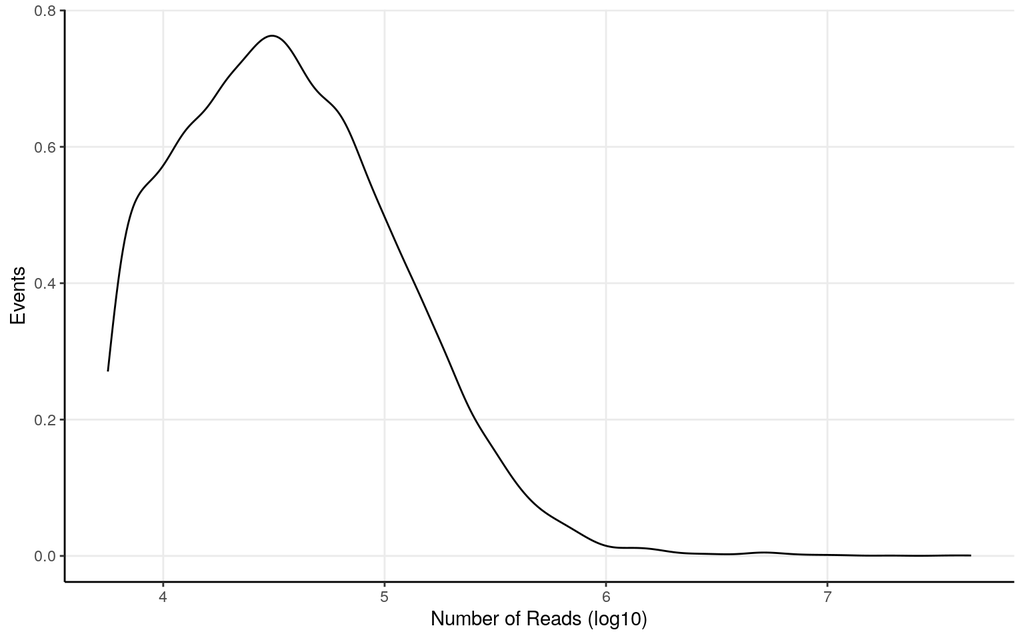

```r
MitoGenes <- fread("~/MitoGenes.txt", header = FALSE)[[1]]
filterednew <- subset(read.counts, alternew>3.75)


#after cutting, its a good idea to visualize again
falternew <- log10(rowSums(filterednew))
falternew <- as.data.frame(falternew)
ggplot(falternew, aes(x=falternew)) + geom_density() + theme_bw() + ylab("Events") + xlab("Number of Reads (log10)") +
  theme(axis.line = element_line(colour = "black"),
        panel.grid.minor = element_blank(),
        panel.border = element_blank(),
        panel.background = element_blank())
```

```r
#lets save the genes which we maintain
impgenes <- c(row.names(falternew), MitoGenes)


#Now we need to select only the rows which have those genes.
finaltable <- read.counts[row.names(read.counts)%in%impgenes,]
```

## Matrices

Good! Now we can proceed by designing our matrices.

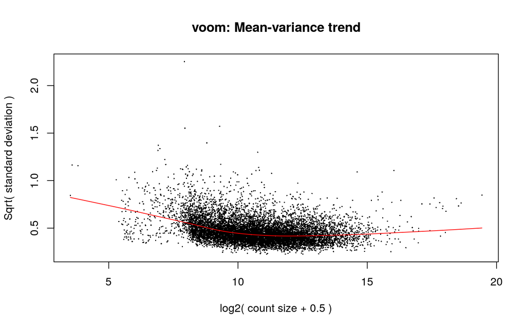

```r
sampletype <- c(rep("PB",3), rep("WC",3),rep("RNP",3),rep("WC",3), rep("SG",3),rep("WC",3))
g3state <- c(rep("WT",3), rep("WT",3),rep("WT",3),rep("WT",3), rep("GFP",3),rep("GFP",3))

metadata <- data.frame(Sample=sampletype, G3=g3state)

#To be able to use Voom, we must first convert our read count table into a special DGE object.
D0 <- DGEList(finaltable)

#for the others, we need to select only relevant columns.

#Then we calculate the normalization factors.
#Bear in mind this step calculates the normalization factors, but does not normalize itself.
D0 <- calcNormFactors(D0)


#Now we do our matrix itself
mm <- model.matrix(~0+sampletype+g3state)

#and now we normalize. This step also turns our counts into log2-counts per million.
y <- voom(D0, mm, plot = T)
```

## Normalisation

For normalisation I convert the read counts into log2CPMs. Its a good way to visualize how the reads are.

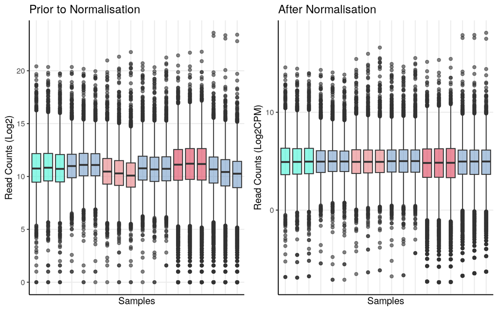

```r
dfforboxy <- finaltable

orderforplots <- sampletype
colouring <- data.frame(Sample=colnames(dfforboxy), Types=orderforplots)
dfforboxy <- reshape2::melt(dfforboxy)
colnames(dfforboxy) <- c("Sample", "Expression")
dfforboxy <- merge(dfforboxy, colouring, by="Sample")
prenorm <- ggplot(dfforboxy, aes(x=Sample, y=(log2(Expression+1)), fill=Types)) + geom_boxplot(alpha=0.6) + theme_bw() + ylab("Read Counts (Log2)") + xlab("Samples") + scale_fill_manual(name = "Sample Type", values = c("#43F3D5", "#769fca", "#e88184", "#de425b"), labels=unique(sampletype), breaks =unique(sampletype)) +
  theme(axis.line = element_line(colour = "black"),
        panel.grid.minor = element_blank(),
        panel.border = element_blank(),
        panel.background = element_blank(),
        axis.text.x=element_blank(),
        axis.ticks.x=element_blank(),
        legend.position = "None") + ggtitle("Prior to Normalisation")

dfforboxy <- y$E
dfforboxy <- reshape2::melt(dfforboxy)
dfforboxy <- dfforboxy[,-1]
colnames(dfforboxy) <- c("Sample", "Expression")
dfforboxy <- merge(dfforboxy, colouring, by="Sample")
postnorm <- ggplot(dfforboxy, aes(x=Sample, y=Expression, fill=Types)) + geom_boxplot(alpha=0.6) + theme_bw() + ylab("Read Counts (Log2CPM)") + xlab("Samples") + scale_fill_manual(name = "Sample Type", values = c("#43F3D5", "#769fca", "#e88184", "#de425b"), labels=unique(sampletype), breaks =unique(sampletype)) +
  theme(axis.line = element_line(colour = "black"),
        panel.grid.minor = element_blank(),
        panel.border = element_blank(),
        panel.background = element_blank(),
        axis.text.x=element_blank(),
        axis.ticks.x=element_blank(),
        legend.position = "None") + ggtitle("After Normalisation")

ggarrange(prenorm, postnorm, nrow=1)
```

## PCA

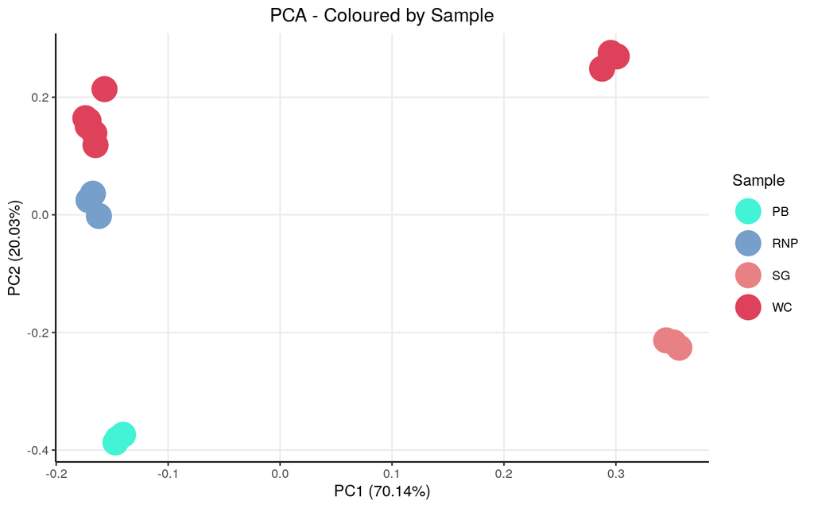

```r
#In here, I am just defining some colours to use
custom_palette <- c("#43F3D5", "#769fca", "#e88184", "#de425b")

#This prepares my data for the PCA
dfforpca <- y$E
dfforpca <- t(dfforpca)
dfforpca <- as.data.frame(dfforpca) # needs to be a data.frame
dfforpca <- apply(dfforpca, 2, as.numeric) # Ensure numeric
dfforpca <- as.data.frame(dfforpca) # still needs to be a data.frame

# Add metadata, which we will then use to plot
dfforpca$Sample <- sampletype
dfforpca$G3 <- g3state

# PCA computation itself. I do one PCA for each variable I want to see.
pca_res <- prcomp(dfforpca[, 1:(ncol(dfforpca)-2)], scale = FALSE)

p_Sample <- autoplot(pca_res, data = dfforpca, x = 1, y = 2, colour = "Sample", size = 8) +
  theme_bw() +
  scale_colour_manual(name = "Sample", values = custom_palette) +
  ggtitle("PCA - Coloured by Sample") +
  theme(plot.title = element_text(hjust = 0.5),
        axis.line = element_line(colour = "black"),
        panel.grid.minor = element_blank(),
        panel.border = element_blank(),
        panel.background = element_blank())

p_g3 <- autoplot(pca_res, data = dfforpca, x = 1, y = 2, colour = "G3", size = 8) +
  theme_bw() +
  scale_colour_manual(name = "G3", values = custom_palette) +
  ggtitle("PCA - Coloured by G3") +
  theme(plot.title = element_text(hjust = 0.5),
        axis.line = element_line(colour = "black"),
        panel.grid.minor = element_blank(),
        panel.border = element_blank(),
        panel.background = element_blank())

p_Sample
```

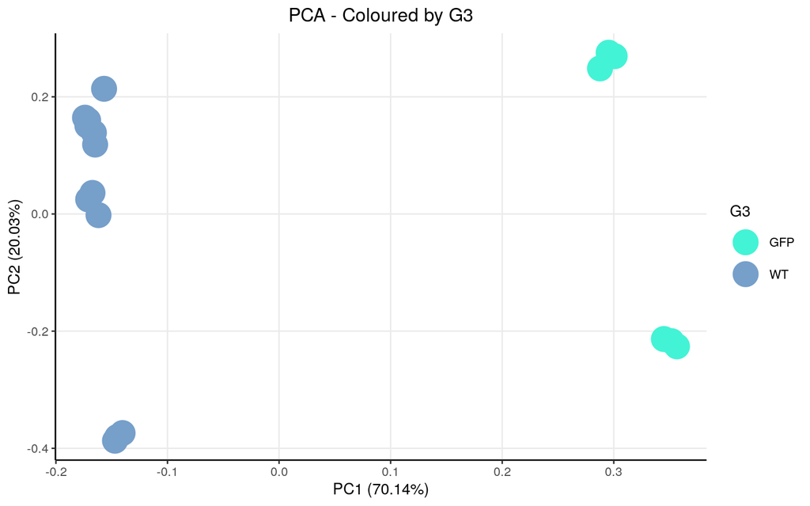

```r
p_g3
```

```r
#in case you want to see most important genes for PCA yourself
contribs1 <- pca_res$rotation[,1]
contribs2 <- pca_res$rotation[,2]

#These are the biggest contributors to the PCA1 (right side)
(pos1genes <- sort(contribs1, decreasing=T)[1:10])
```

```
##     MAGEC1    MT-RNR2  LINC02074    EXOC3L2    MT-RNR1     KLHL26    ZNF542P
## 0.04843049 0.04680164 0.04667420 0.04437938 0.03675231 0.03272461 0.02700095
##      IFI44     TRIML2   ADAMTSL1
## 0.02672032 0.02601783 0.02539868
```

```r
#These are the biggest contributors to the PCA1 (left side)
(neg1genes <- sort(contribs1, decreasing=F)[1:10])
```

```
##          RN7SK         RN7SL2          RPPH1          EEF1G            7SK
##    -0.09235204    -0.09000551    -0.08107753    -0.07774858    -0.07691841
##         EIF4A1      NME1-NME2 BLOC1S5-TXNDC5    RPS10-NUDT3   PEDS1-UBE2V1
##    -0.07662947    -0.07470534    -0.07272797    -0.07023587    -0.06981692
```

```r
#These are the biggest contributors to the PCA2 (up side)
(pos2genes <- sort(contribs2, decreasing=T)[1:10])
```

```
##     RN7SL1     RN7SL3    RN7SL4P    RN7SL5P   RN7SKP80   SCARNA16    SNORD3A
## 0.07494386 0.07324077 0.06537981 0.06272589 0.05175981 0.04817578 0.04786311
##    SNORA23   SNORA73A     RNU4-2
## 0.04673976 0.04596904 0.04424736
```

```r
#These are the biggest contributors to the PCA2 (down side)
(neg2genes <- sort(contribs2, decreasing=F)[1:10])
```

```
##       MT-TG       MT-TR      AHNAK2      BOD1L1     SHROOM3        ROR1
## -0.03411113 -0.02614144 -0.02534601 -0.02510791 -0.02504408 -0.02477080
##       SYNE2       HIPK2      ZNF107       PRKDC
## -0.02464201 -0.02440437 -0.02434585 -0.02422321
```

As one can observe from the PCAs, our PC1 is mostly explained by G3 status, while our PC2 is explained by sample type. For this particular experiment, in my opinion, G3 status isn’t relevant, so I will batch correct for that.

## Batch Effect Correction

```r
#This is the code I used to correct batch effect. It is based on the one we used in Schneider et al. (2024), aka voyAGEr.
batch_cols <- c("G3") #We define which variable we want to treat as batch effects
metadata_cols <- c("Sample") #And those we dont want to treat as such
#This creates a new matrix with all our variables of interest
mmbatch <- model.matrix(reformulate(paste0("~0 + ",paste0( batch_cols,collapse = " + "))), data=metadata)
mmkeep <- model.matrix(reformulate(paste0("~0 + ",paste0( metadata_cols,collapse =  "+" ))), data=metadata)
mm <- cbind(mmkeep,mmbatch)
#Now, we apply the new model
D0 <- DGEList(2^y$E) #I use the normalised counts, but these must be "unloged". Hence the 2^
D0 <- calcNormFactors(D0)
y <- voom(D0, mm, plot = F)
```

```
## Coefficients not estimable: G3WT
```

```r
fit <- lmFit(y, mm)
```

```
## Coefficients not estimable: G3WT
```

```r
#Basicly, we determine what coefficients are originated from our batch variable, and we remove those across the data
beta <- fit$coefficients[,-(1:ncol(mmkeep)),drop=FALSE]
beta[is.na(beta)] <- 0 #In the case of binary variables, one of them wont have "any effect" and will thus be NA. This corrects for that step.
corrcounts_v1 <- as.matrix(y$E) - beta %*% t(mmbatch)
offset <- apply(corrcounts_v1,1,min) - apply(y$E,1,min) #This gives the offset itself that needs to be applied
corrcounts_v1 <- as.data.frame(corrcounts_v1-offset)
corrcounts_v1 <- 2^corrcounts_v1 #I prefer to unlog them, to have a dataframe of non-log CPMs, in case I need.
```

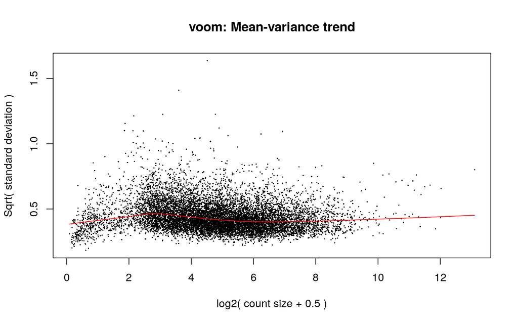

```r
# Now we simply generate new log CPM expression values, starting from the correct expression values.
mm <- model.matrix(~0+Sample, metadata)
y <- voom(corrcounts_v1, mm, plot = T)
```

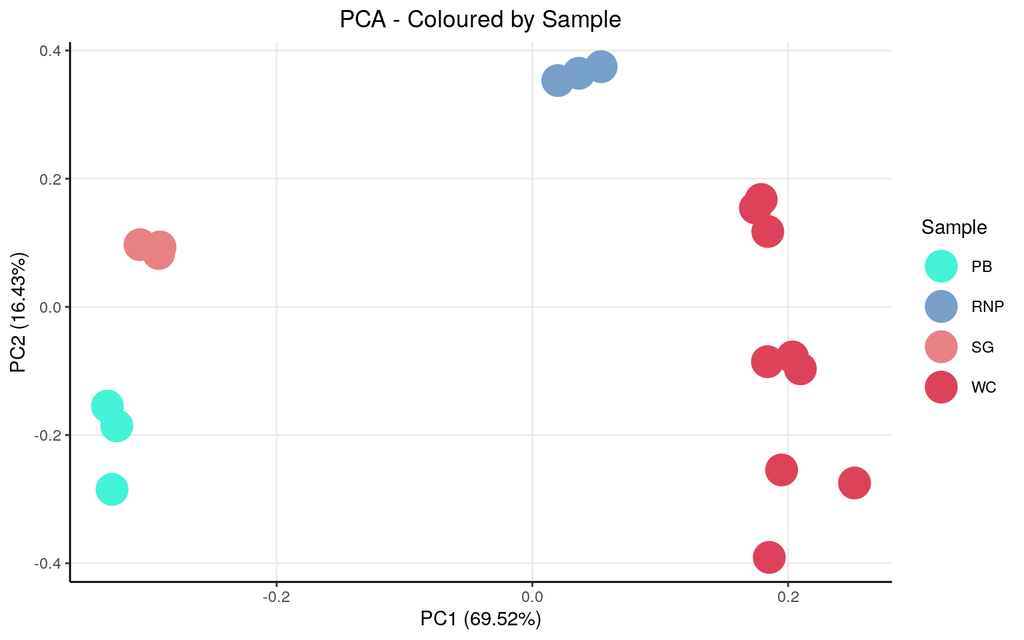

```r
#This prepares my data for the PCA
dfforpca <- y$E
dfforpca <- t(dfforpca)
dfforpca <- as.data.frame(dfforpca) # needs to be a data.frame
dfforpca <- apply(dfforpca, 2, as.numeric) # Ensure numeric
dfforpca <- as.data.frame(dfforpca) # still needs to be a data.frame

# Add metadata, which we will then use to plot
dfforpca$Sample <- sampletype
dfforpca$G3 <- g3state

# PCA computation itself. I do one PCA for each variable I want to see.
pca_res <- prcomp(dfforpca[, 1:(ncol(dfforpca)-3)], scale = FALSE)

p_Sample <- autoplot(pca_res, data = dfforpca, x = 1, y = 2, colour = "Sample", size = 8) +
  theme_bw() +
  scale_colour_manual(name = "Sample", values = custom_palette) +
  ggtitle("PCA - Coloured by Sample") +
  theme(plot.title = element_text(hjust = 0.5),
        axis.line = element_line(colour = "black"),
        panel.grid.minor = element_blank(),
        panel.border = element_blank(),
        panel.background = element_blank())

p_g3 <- autoplot(pca_res, data = dfforpca, x = 1, y = 2, colour = "G3", size = 8) +
  theme_bw() +
  scale_colour_manual(name = "G3", values = custom_palette) +
  ggtitle("PCA - Coloured by G3") +
  theme(plot.title = element_text(hjust = 0.5),
        axis.line = element_line(colour = "black"),
        panel.grid.minor = element_blank(),
        panel.border = element_blank(),
        panel.background = element_blank())

p_Sample
```

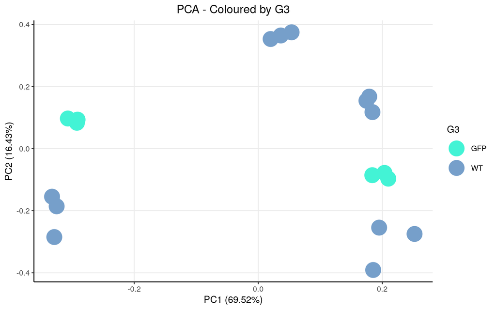

```r
p_g3
```

```r
#in case you want to see most important genes for PCA yourself
contribs1 <- pca_res$rotation[,1]
contribs2 <- pca_res$rotation[,2]

#These are the biggest contributors to the PCA1 (right side)
(pos1genes <- sort(contribs1, decreasing=T)[1:10])
```

```
##     RN7SL1     RN7SL3    RN7SL4P    SNORD3A   SNORA73A     RNU4-2     RNU4-1
## 0.07819149 0.07338003 0.06039211 0.05240663 0.04344117 0.04162159 0.04111815
##       H4C9       H3C2   SNORA73B
## 0.03993034 0.03970203 0.03950063
```

```r
#These are the biggest contributors to the PCA1 (left side)
(neg1genes <- sort(contribs1, decreasing=F)[1:10])
```

```
##      BOD1L1      AHNAK2       SYNE2       AHNAK       HIPK2     ANKRD11
## -0.02318433 -0.02289697 -0.02241877 -0.02225151 -0.02222807 -0.02189860
##       PRKDC       MAP1A        SPEN       HERC2
## -0.02163812 -0.02156988 -0.02145341 -0.02136532
```

```r
#These are the biggest contributors to the PCA2 (up side)
(pos2genes <- sort(contribs2, decreasing=T)[1:10])
```

```
##      MT-TN     MT-TS1      MT-TA      HSPA6     BCYRN1    MARCHF4      MT-TK
## 0.14628241 0.08431778 0.08124052 0.06283742 0.05859411 0.04661833 0.04613320
##  SPATA31G1     MT-TL1   CDRT15P9
## 0.04612792 0.04552648 0.04397064
```

```r
#These are the biggest contributors to the PCA2 (down side)
(neg2genes <- sort(contribs2, decreasing=F)[1:10])
```

```
##  CSGALNACT1   TNFRSF11B        FUT1        ROR1        SOX2       SESN3
## -0.05822065 -0.05353779 -0.05232869 -0.04835696 -0.04745489 -0.04704362
##       CXCL8        HAS2      SEMA3A      CXCL14
## -0.04568378 -0.04503400 -0.04391388 -0.04238995
```

After batch correction, as one can observe from the PCAs, our PC1 is now explained by sample type.

Now I will directly compare the 3 granule types to the whole cell.

# PB vs WC

## Linear Models

Now we must perform linear model fitting.

```r
fitted <- lmFit(y, mm)
head(coef(fitted))
```

```
##           SamplePB SampleRNP SampleSG SampleWC
## 7SK      0.3585752  4.554946 5.577907 6.164172
## A1BG-AS1 3.1174872  3.066850 3.178445 2.414839
## A2M      2.7090238  3.859096 3.382536 3.295809
## AAAS     4.1105954  5.487700 4.486423 5.649326
## AACS     5.1200856  6.119243 5.051033 5.792689
## AADAT    3.0913157  4.016408 3.646845 4.040018
```

```r
#next we measure contrasts between groups (log-fold change is obtained from these fitted linear models)
contr<- makeContrasts(SamplePB       - SampleWC       , levels = colnames(coef(fitted)))

#next we estimate the contrast for each gene
tmp <- contrasts.fit(fitted, contr)


#use empirical bayes smoothing of standard erros (shrinks extreme standard erros)
tmp <- eBayes(tmp)
top.table <- topTable(tmp, sort.by = "logFC", n = Inf)
DEGenes <- top.table
ndegs=20
```

## Volcano Plots

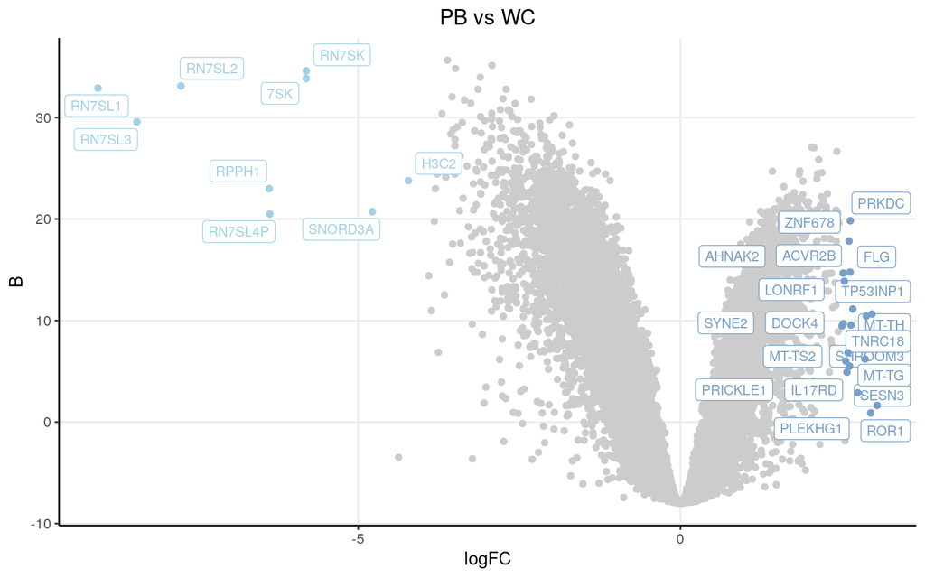

```r
upmarkers <- as.data.frame(DEGenes[DEGenes$logFC>2.5 & DEGenes$B>0,] )
downmarkers <- as.data.frame(DEGenes[DEGenes$logFC< -4 & DEGenes$B>0,] )

ggplot(data=DEGenes,
                 aes(x=logFC,
                     y=  B)) +
  geom_point(color="#CCCCCC")+
  theme_bw() +
  theme(axis.line = element_line(colour = "black"),
        panel.grid.minor = element_blank(),
        panel.border = element_blank(),
        panel.background = element_blank()) +
  ggtitle("PB vs WC")+
  theme(plot.title = element_text(hjust = 0.5)) +
  geom_label_repel(upmarkers[1:ndegs,] , mapping=aes(label=row.names(upmarkers)[1:ndegs]),size=3,point.padding=-0.5, color="#769fca",max.overlaps = 20)+
  geom_label_repel(downmarkers[1:ndegs,] , mapping=aes(label=row.names(downmarkers)[1:ndegs]),size=3,point.padding=-0.5, color="#a2d1e6",max.overlaps = 20)+
  geom_point(data=upmarkers, aes(x=logFC, y=  B), color="#769fca")+
  geom_point(data=downmarkers, aes(x=logFC, y=  B), color="#a2d1e6")
```

```r
#write.table(DEGenes, "~/Projects/StressGranules/SGPAPER/RealSGs/Tmathenypb.txt", row.names = T)
#rnp_t <- data.frame(Gene=row.names(DEGenes), rnp_t=DEGenes$t, rnp_logFC=DEGenes$logFC)
pb_t <- data.frame(Gene=row.names(DEGenes), pb_t=DEGenes$t)
#sg_t <- data.frame(Gene=row.names(DEGenes), sg_t=DEGenes$t, sg_logFC=DEGenes$logFC)
```

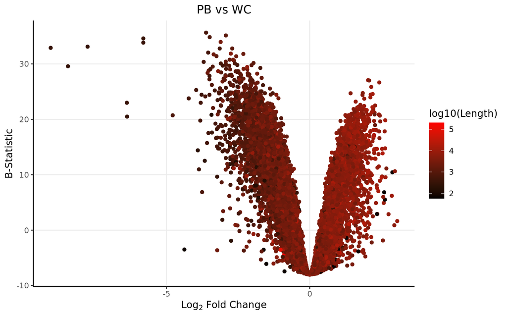

```r
DEGenes$Gene <- row.names(DEGenes)
colnames(genelength) <- c("Length","Gene")
DEGenes <- merge(DEGenes, genelength, by="Gene")

Pbody <- DEGenes[,c(1,2,4,8)]

ggplot(data=DEGenes,
                 aes(x=logFC,
                     y=  B)) +
  geom_point(aes(color=log10(Length)))+
  theme_bw() +
  theme(axis.line = element_line(colour = "black"),
        panel.grid.minor = element_blank(),
        panel.border = element_blank(),
        panel.background = element_blank()) +
  ggtitle("PB vs WC")+ xlab(expression(Log[2] ~ Fold ~ Change)) + ylab("B-Statistic") +
  theme(plot.title = element_text(hjust = 0.5))  +
  scale_colour_gradient(low = "black", high = "red")+ theme(text=element_text(family = "Quicksand"))
```

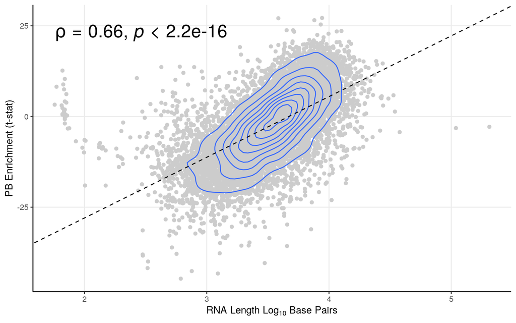

```r
smooth.SG <- lm(t~log10(Length), DEGenes)

ggplot(DEGenes, aes(y=t, x=log10(Length))) + geom_point(color="#CCCCCC", alpha=1) +   theme_bw()+ geom_density_2d()+
 ylab("PB Enrichment (t-stat)") + xlab(expression(RNA ~ Length ~ Log[10] ~ Base ~ Pairs)) +
  theme(axis.line = element_line(colour = "black"),
        panel.grid.minor = element_blank(),
        panel.border = element_blank(),
        panel.background = element_blank()) +
  theme(plot.title = element_text(hjust = 0.5))  +
  geom_abline(slope=smooth.SG$coefficients[2], intercept = smooth.SG$coefficients[1], linetype = "dashed")+ stat_cor(method = "spearman", cor.coef.name = "rho",size=7)
```